# Projekt z analizy dany

## Porównanie strzałów celnych i niecelnych

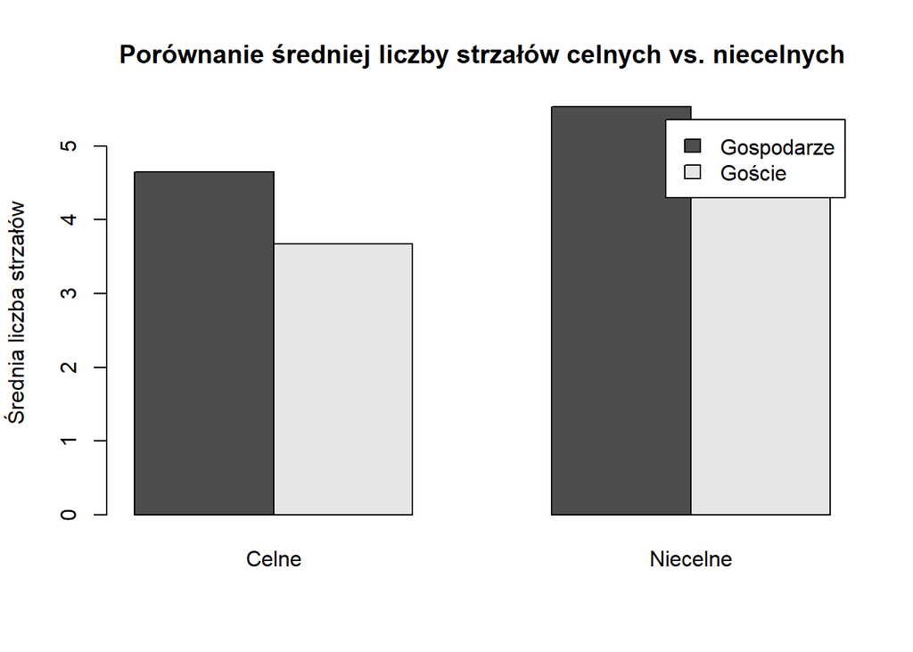

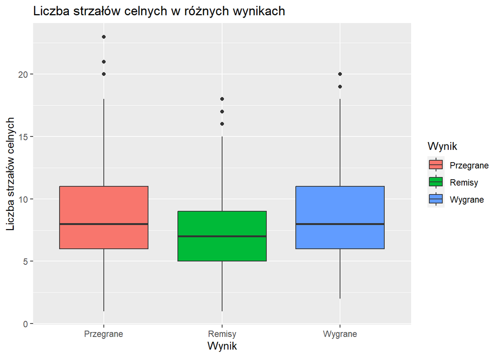

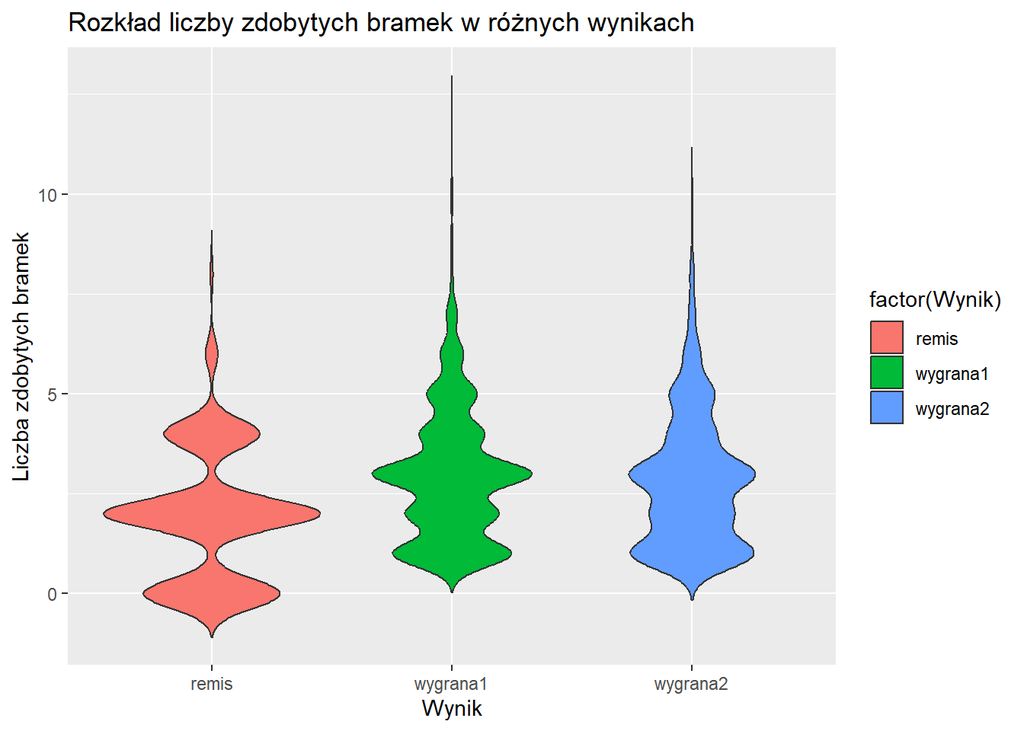

# Macierz korelacji i testy

## Dla Gości

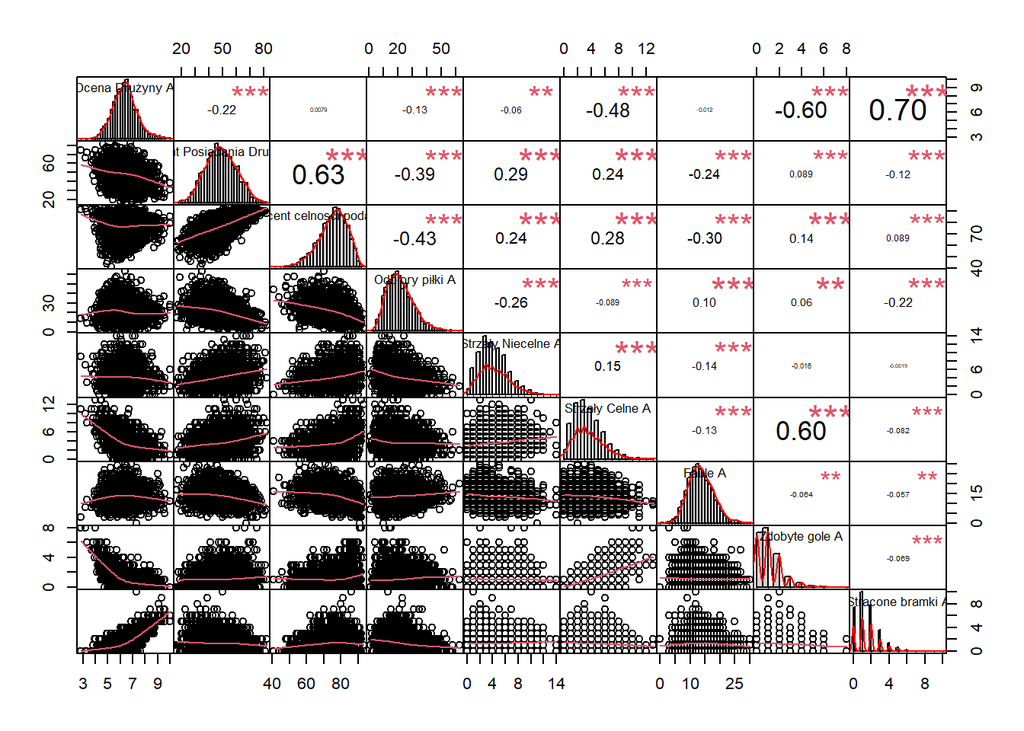

```
    Pearson's Chi-squared test

data:  dane$`Faule A` and dane$`I połowa karki żółte A` + dane$`II połowa żółte kartki A` +
    dane$`Czerwone kartki A`
X-squared = 1153, df = 280, p-value < 2.2e-16
```

```
    Pearson's product-moment correlation

data:  dane$`Faule A` and dane$`I połowa karki żółte A` + dane$`II połowa żółte kartki A` + dane$`Czerwone kartki A`
t = 18.778, df = 2658, p-value < 2.2e-16
alternative hypothesis: true correlation is not equal to 0
95 percent confidence interval:
 0.3082399 0.3753589
sample estimates:
      cor
0.3422359
```

### **Wyniki analizy dla drużyn gości:**

- **Test chi-kwadrat:** Wynik testu chi-kwadrat wyniósł X-squared = 1153, df = 280, p-value < 2.2e-16. Sugeruje to istnienie statystycznie istotnej zależności między liczbą fauli popełnionych przez drużynę gości a liczbą otrzymanych żółtych i czerwonych kartek.
- **Test korelacji Pearsona:** Wynik testu korelacji Pearsona wyniósł t = 18.778, df = 2658, p-value < 2.2e-16. Wartość współczynnika korelacji wynosi około 0.342, co wskazuje na umiarkowaną dodatnią korelację między liczbą fauli a liczbą otrzymanych kartek dla drużyn gości.

## Dla Gospodarzy

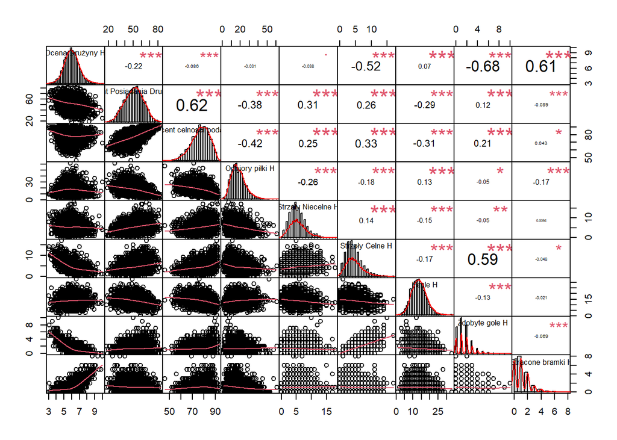

```
    Pearson's Chi-squared test

data:  dane$`Faule H` and dane$`I połowa karki żółte H` + dane$`II połowa żółte kartki H` +
    dane$`Czerwone kartki H`
X-squared = 728.17, df = 261, p-value < 2.2e-16
```

```
    Pearson's product-moment correlation

data:  dane$`Faule H` and dane$`I połowa karki żółte H` + dane$`II połowa żółte kartki H` + dane$`Czerwone kartki H`
t = 20.257, df = 2658, p-value < 2.2e-16
alternative hypothesis: true correlation is not equal to 0
95 percent confidence interval:
 0.3323052 0.3981634
sample estimates:
     cor
0.365692
```

### **Wyniki analizy dla drużyn gospodarzy:**

- **Test chi-kwadrat:** Wynik testu chi-kwadrat wyniósł X-squared = 728.17, df = 261, p-value < 2.2e-16. Oznacza to, że istnieje statystycznie istotna zależność między liczbą fauli popełnionych przez drużynę gospodarzy a liczbą otrzymanych żółtych i czerwonych kartek.
- **Test korelacji Pearsona:** Wynik testu korelacji Pearsona wyniósł t = 20.257, df = 2658, p-value < 2.2e-16. Wartość współczynnika korelacji wynosi około 0.366, co wskazuje na umiarkowaną dodatnią korelację między liczbą fauli a liczbą otrzymanych kartek.